# Backward Selection

Shan Chen

4/12/2020

```r
suppressWarnings(library(tidyverse))
```

# Introduction

The selection algorithms are described in section 6.1 of ISLR.

Here, we will implement the Forward Selection Algorithm (*Algorithm 6.2*) using cross-validated MSE as the final determiner of the optimal model. The plan, as outlined in *Algorithm 6.2*, is relatively simple.

# The Data: Election Turnout Prediction

The data files are related to the presidential election of 2012 (Romney vs Obama):

- countyElection.csv: For each US county, demographic data along with voter turnout rates
- county_facts_dictionary.csv: A data dictionary containing descriptions of each of the demographic fields in countyElection.csv.

Establish data locations and read the data.

```r
dataDir <- "/Users/shawnchen/Desktop"
dataFile <- "CountyElection.csv"
dictFile <- "County_Facts_Dictionary.csv"

countyElection.df <- read.csv(file.path(dataDir,dataFile))
names(countyElection.df)
```

```
##  [1] "fips"      "PST045214" "AGE135214" "AGE295214" "AGE775214" "SEX255214"
##  [7] "RHI125214" "RHI225214" "RHI325214" "RHI425214" "RHI525214" "RHI625214"
## [13] "RHI725214" "RHI825214" "POP715213" "POP645213" "POP815213" "EDU635213"
## [19] "EDU685213" "VET605213" "LFE305213" "HSG010214" "HSG445213" "HSG096213"
## [25] "HSG495213" "HSD410213" "HSD310213" "INC910213" "INC110213" "PVY020213"
## [31] "BZA010213" "BZA110213" "BZA115213" "NES010213" "SBO001207" "SBO315207"
## [37] "SBO115207" "SBO215207" "SBO515207" "SBO415207" "SBO015207" "MAN450207"
## [43] "WTN220207" "RTN131207" "AFN120207" "BPS030214" "POP060210" "State"
## [49] "VoterProp"
```

```r
dictionary.df <-
    read.csv(file.path(dataDir,dictFile))
dim(countyElection.df)
```

```
## [1] 2711   49
```

What sort of predictors do we have?

Take a peek at the top of the dicgtio

```r
head(dictionary.df,10)
```

```
##    column_name                                                     description
## 1    PST045214                                       Population, 2014 estimate
## 2    AGE135214                            Persons under 5 years, percent, 2014
## 3    AGE295214                           Persons under 18 years, percent, 2014
## 4    AGE775214                        Persons 65 years and over, percent, 2014
## 5    SEX255214                                   Female persons, percent, 2014
## 6    RHI125214                                      White alone, percent, 2014
## 7    RHI225214                  Black or African American alone, percent, 2014
## 8    RHI325214          American Indian and Alaska Native alone, percent, 2014
## 9    RHI425214                                      Asian alone, percent, 2014
## 10   RHI525214 Native Hawaiian and Other Pacific Islander alone, percent, 2014
```

and the bottom.

```r
tail(dictionary.df,10)
```

```
##    column_name
## 37   SBO215207
## 38   SBO515207
## 39   SBO415207
## 40   SBO015207
## 41   MAN450207
## 42   WTN220207
## 43   RTN131207
## 44   AFN120207
## 45   BPS030214
## 46   POP060210
##                                                               description
## 37                                       Asian-owned firms, percent, 2007
## 38 Native Hawaiian- and Other Pacific Islander-owned firms, percent, 2007
## 39                                    Hispanic-owned firms, percent, 2007
## 40                                       Women-owned firms, percent, 2007
## 41                                 Manufacturers shipments, 2007 ($1,000)
## 42                               Merchant wholesaler sales, 2007 ($1,000)
## 43                                          Retail sales per capita, 2007
## 44                   Accommodation and food services sales, 2007 ($1,000)
## 45                                                 Building permits, 2014
## 46                                       Population per square mile, 2010
```

```r
countyIDInfo.df <- countyElection.df %>%
  select(fips,State)

countyElection.df <- countyElection.df %>%
  select(-fips,-State)

dictionary.df <- dictionary.df %>%
  filter(! column_name %in% c("fips","State"))
```

What do we have, dimension-wise

```r
dim(countyElection.df)
```

```
## [1] 2711   47
```

```r
numPreds <- ncol(countyElection.df)-1
```

```r
## the available and model predictors
availPreds <- 1:numPreds
modelPreds <- c()
```

Now we are ready for the main loop.

## Main Loop

Note: prints some relevant information as it goes along so you can track the progress.

```r
## keep track of the R2 for reference
maxR2 <- c()
##Keep going as long as there are available predictors left
while(length(availPreds) > 0){
    ##add predictor which increases R^2 the most
    ##keep track of the R^2 values for reference
    allR2 <- c()
    for(id in availPreds){
      ##the augmented predictors
      augPreds <- c(modelPreds,id)
      ## Build the data frame with the augmented predictors
      data.df <- countyElection.df[,c(augPreds,numPreds+1)]
      ##the model and its summary
      mod.curr <- lm(VoterProp ~ .,
                     data=data.df)
      mod.sum <- summary(mod.curr)
      ##grab the R^2
      allR2 <- c(allR2,mod.sum$r.squared)
    }
    ##Find the index of the min R^2
    max.id <- which.max(allR2)
    ##get the best predictor and R^2
    bestPred <- availPreds[max.id]
    bestR2 <- max(allR2)
    ##Add these into the collection
    modelPreds <- c(modelPreds,bestPred)
    ## remove the  bestPred from  the availPreds
    availPreds <- setdiff(availPreds,bestPred)
    maxR2 <- c(maxR2,bestR2)
    ##remove bestsPred from avail
    ## Print stuff out for debugging and attention-grabbing
    print(sprintf("Pred Added: %s  R^2 Value: %s",bestPred,round(bestR2,3)))
    ##print(modelPreds)
}
```

```
## [1] "Pred Added: 17  R^2 Value: 0.226"
## [1] "Pred Added: 14  R^2 Value: 0.383"
## [1] "Pred Added: 7  R^2 Value: 0.442"
## [1] "Pred Added: 4  R^2 Value: 0.504"
## [1] "Pred Added: 11  R^2 Value: 0.532"
## [1] "Pred Added: 33  R^2 Value: 0.554"
## [1] "Pred Added: 15  R^2 Value: 0.577"
## [1] "Pred Added: 27  R^2 Value: 0.587"
## [1] "Pred Added: 3  R^2 Value: 0.601"
## [1] "Pred Added: 22  R^2 Value: 0.605"
## [1] "Pred Added: 20  R^2 Value: 0.61"
## [1] "Pred Added: 18  R^2 Value: 0.613"
## [1] "Pred Added: 26  R^2 Value: 0.616"
## [1] "Pred Added: 43  R^2 Value: 0.618"
## [1] "Pred Added: 30  R^2 Value: 0.621"
```

[output cut: 31 more lines]

The process creates an increasing sequence of (nested) models with increasing R^2. After a while, the increase in R^2 tails off. This is how R^2 works, it is a non-decreasing function of the number of predictors.

## MSE via Cross-validation of each model

Out of all these models, we now want to find the “best” one. In this case, “best” is defined as having the smallest MSE, as determined by cross-validation. We expect that the model with all the predictors might be over-fitting the data. On the other hand, the model with just one predictor doesn’t have enough predictive power. Somewhere in betweeen is the best model. Let’s find it.

It will help to have a help function to compute the cross-validated MSE.

```r
## args: a data frame and a number of folds (default to 10).
## ret: k-fold cross-validated MSE
mseCV <- function(data.df,numFolds=10){
  dataSize <- nrow(data.df)
  folds <- sample(1:numFolds,dataSize,rep=T)
  mse <- numeric(numFolds)
  fold <- 5
  for(fold in 1:numFolds){
    train.df <- data.df[folds != fold,]
    test.df <- data.df[folds == fold,]
    mod <- lm(VoterProp  ~ .,
              data=train.df)
    vals <- predict(mod,newdata=test.df)
    mse[fold] <- with(test.df,mean((VoterProp-vals)^2))
  }
  mean(mse)
}
```

Here’s an example of how we will use this function. Suppose we want to estimate the MSE for the model with exactly 15 predictors.

```r
totPred <- 15
modelPreds[1:totPred]
```

```
##  [1] 17 14  7  4 11 33 15 27  3 22 20 18 26 43 30
```

```r
data.df <- countyElection.df[, c(modelPreds[1:totPred],numPreds+1)]
mseCV(data.df)
```

```
## [1] 0.003904469
```

Ok, that was easy. Apply the process to the sequence 1,2,….numPreds.

Use map_dbl to simplify the work. This means we need to build an “anonymous function” inside of map_dbl.

```r
allMSE <- map_dbl(1:numPreds,
                  function(totPred)
                 mseCV(countyElection.df[,c(modelPreds[1:totPred],numPreds+1)]))
```

## Visualization

Let’s see what we have.

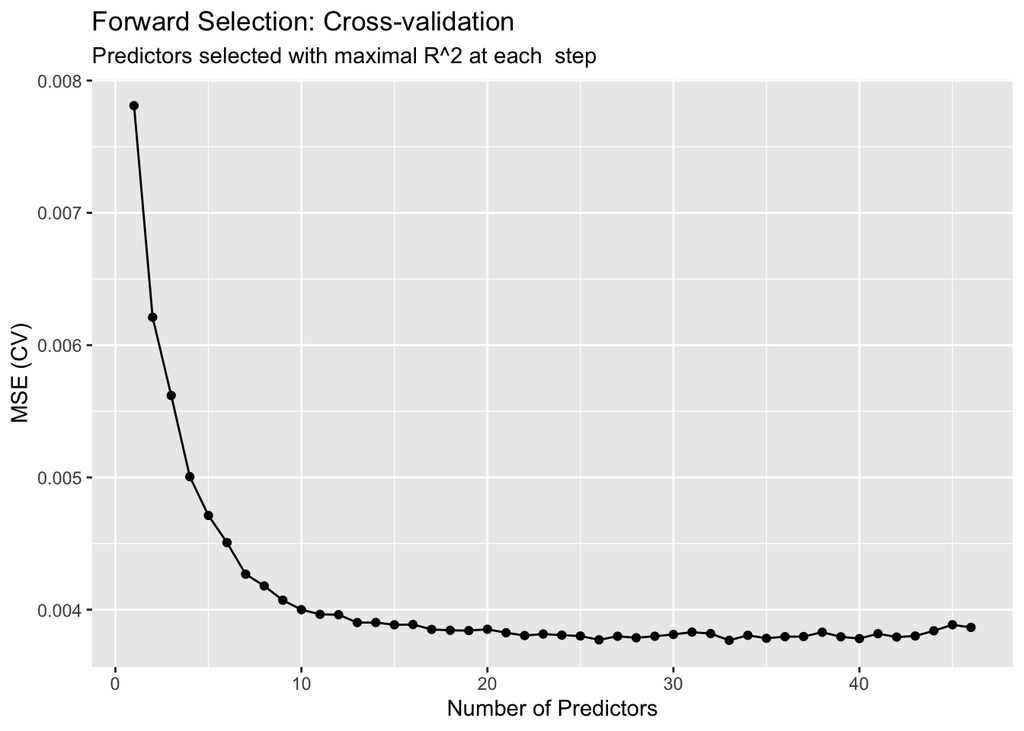

```r
data.frame(numPred=1:numPreds,
           mse=allMSE) %>%
  ggplot()+
  geom_point(aes(numPred,mse))+
  geom_line(aes(numPred,mse))+
  labs(title="Forward Selection: Cross-validation",
       subtitle="Predictors selected with maximal R^2 at each  step",
       x = "Number of Predictors",
       y = "MSE (CV)")
```

It looks as if the optimal model has around 20 or fewer predictors.

## Optimal Model: One Standard Error Rule

So how do we pick the optimal model? There are two issues in play here. First, we want to minimize MSE. Second, we want to be parsimonious, that is, we want the simplest model (fewest predictors) possible.

To balance these two competing goals, we can use the “One Standard Error Rule” which states use the simplest model within one standard error of the minimum MSE model.

We didn’t track the SE in our original function, but we can easily modify it to compute the SE as well.

```r
## args: a data frame and a number of folds (default to 10).
## ret: k-fold cross-validated MSE and the Standard Error
mseCV_SE <- function(data.df,numFolds=10){
  dataSize <- nrow(data.df)
  folds <- sample(1:numFolds,dataSize,rep=T)
  mse <- numeric(numFolds)
  for(fold in 1:numFolds){
    train.df <- data.df[folds !=fold,]
    test.df <- data.df[folds==fold,]
    mod <- lm(VoterProp  ~ .,
              data=train.df)
    vals <- predict(mod,newdata=test.df)
    mse[fold] <- with(test.df,mean((VoterProp-vals)^2))
  }
  c(mean(mse),sqrt(var(mse)/numFolds))
}
```

```r
(predMin <- which.min(allMSE))
```

```
## [1] 33
```

```r
##build this model
data.df <- countyElection.df[,c(modelPreds[1:predMin],numPreds+1)]
## get  both the MSE  estimate and the SE
(mseInfo <- mseCV_SE(data.df))
```

```
## [1] 0.0038722281 0.0002137762
```

Now we need to identify the smallest predictor set within one SE of the min MSE.

```r
## add the MSE and the SE.
mseCut <- mseInfo[1]+mseInfo[2]
##
(thePreds <- (1:numPreds)[allMSE < mseCut])
```

```
##  [1]  9 10 11 12 13 14 15 16 17 18 19 20 21 22 23 24 25 26 27 28 29 30 31 32 33
## [26] 34 35 36 37 38 39 40 41 42 43 44 45 46
```

We can use the predictors starting at the minimum index.

```r
(optNumPreds <- min(thePreds))
```

```
## [1] 9
```

```r
(preds.forward <- modelPreds[1:optNumPreds])
```

```
## [1] 17 14  7  4 11 33 15 27  3
```

The cross-validated estimated MSE has already been computed.

```r
(forwardMSE <- allMSE[optNumPreds])
```

```
## [1] 0.004071851
```

Now we have really reduced the number of predictors and have a very reasonable MSE. Which predictors are these??

#Backward selection

```r
availPreds <- 1:numPreds
modelPreds <- c()
while(length(availPreds) >1){
  allR2 <- c()
  pred <- 1
  for(pred in availPreds){
    testPreds <- setdiff(availPreds,pred)
    data.df <- countyElection.df[,c(testPreds,numPreds+1)]
    mod <- lm(VoterProp ~ ., data=data.df)
    mod.sum <- summary(mod)
    allR2 <- c(allR2,mod.sum$r.squared)
  }
  max.id <- which.max(allR2)
  bestPred <- availPreds[max.id]
  ##tack the best predictor on the front
  modelPreds <- c(bestPred,modelPreds)
  availPreds <- setdiff(availPreds,bestPred)
  print(sprintf("Pred Added: %s  R^2 Value: %s",bestPred,round(allR2[max.id],3)))
}
```

```
## [1] "Pred Added: 6  R^2 Value: 0.642"
## [1] "Pred Added: 44  R^2 Value: 0.642"
## [1] "Pred Added: 19  R^2 Value: 0.642"
## [1] "Pred Added: 23  R^2 Value: 0.642"
## [1] "Pred Added: 46  R^2 Value: 0.642"
## [1] "Pred Added: 35  R^2 Value: 0.642"
## [1] "Pred Added: 29  R^2 Value: 0.642"
## [1] "Pred Added: 32  R^2 Value: 0.642"
## [1] "Pred Added: 10  R^2 Value: 0.642"
## [1] "Pred Added: 28  R^2 Value: 0.642"
## [1] "Pred Added: 40  R^2 Value: 0.642"
## [1] "Pred Added: 42  R^2 Value: 0.642"
## [1] "Pred Added: 39  R^2 Value: 0.641"
## [1] "Pred Added: 36  R^2 Value: 0.641"
## [1] "Pred Added: 34  R^2 Value: 0.64"
```

[output cut: 30 more lines]

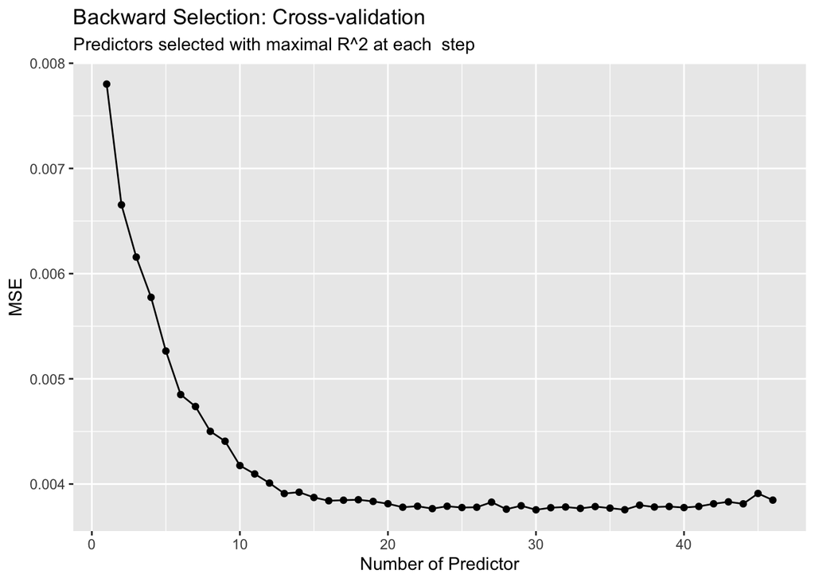

```r
## Tack the last one on the front
modelPreds <- c(availPreds,modelPreds)
# Cross-validate
allMSE <- map_dbl(1:numPreds, function(tot) mseCV(countyElection.df[,c(modelPreds[1:tot],numPreds+1)]))
###
data.frame(numPreds=1:numPreds,MSE=allMSE) %>%
  ggplot()+
  geom_point(aes(numPreds,MSE))+
  geom_line(aes(numPreds,MSE))+
  labs(title="Backward Selection: Cross-validation",
       subtitle="Predictors selected with maximal R^2 at each  step",
       x="Number of Predictor")
```

```r
## 1 SE Rule
(predMin <- which.min(allMSE) )
```

```
## [1] 30
```

```r
##build this model
data.df <- countyElection.df[,c(modelPreds[1:predMin],numPreds+1)]
## get  both the MSE  estimate and the SE
(mseInfo <- mseCV_SE(data.df))
```

```
## [1] 0.0037630989 0.0001645431
```

```r
## add the MSE and the SE.
mseCut <- mseInfo[1]+mseInfo[2]
##
(thePreds <- (1:numPreds)[allMSE < mseCut])
```

```
##  [1] 13 14 15 16 17 18 19 20 21 22 23 24 25 26 27 28 29 30 31 32 33 34 35 36 37
## [26] 38 39 40 41 42 43 44 45 46
```

```r
#
(optNumPreds <- min(thePreds))
```

```
## [1] 13
```

```r
(preds.backward <- modelPreds[1:optNumPreds])
```

```
##  [1] 17  4 11 12 13 14  8  3 18 15 30 22 43
```

```r
# How does this compare  to the original forward selection predictors?
sort(preds.forward)
```

```
## [1]  3  4  7 11 14 15 17 27 33
```

```r
sort(preds.backward)
```

```
##  [1]  3  4  8 11 12 13 14 15 17 18 22 30 43
```